# Project 6

### AB-Project 6

### Titanic Dataset

**Attributes**

- Survived: 0 = Not survived, 1 = Survived
- Pclass: Ticket class 1 = 1st class, 2 = 2nd class, 3 = 3rd class
- Name: Name of passenger
- Sex: male, female
- Age: Age of passenger
- Sibsp: # of siblings / spouses aboard the Titanic
- Parch: # of parents / children aboard the Titanic
- Ticket: Ticket number
- Fare: Passenger fare
- Cabin: Cabin number
- Embarked: Port of Embarkation C = Cherbourg, Q = Queenstown, S = Southampton

**Question1: Import the required libraries and read Titanic.csv file and save it in df dataframe, display the first five rows of df dataframe**

```python
import pandas as pd
from sklearn import tree
import matplotlib.pyplot as plt

df = pd.read_csv('Titanic.csv')
df.head()
```

|  | PassengerId | Survived | Pclass | Name | Sex | Age | SibSp | Parch | Ticket | Fare | Cabin | Embarked |
| --- | --- | --- | --- | --- | --- | --- | --- | --- | --- | --- | --- | --- |
| 0 | 1 | 0 | 3 | Braund, Mr. Owen Harris | male | 22.0 | 1 | 0 | A/5 21171 | 7.2500 | NaN | S |
| 1 | 2 | 1 | 1 | Cumings, Mrs. John Bradley (Florence Briggs Th... | female | 38.0 | 1 | 0 | PC 17599 | 71.2833 | C85 | C |
| 2 | 3 | 1 | 3 | Heikkinen, Miss. Laina | female | 26.0 | 0 | 0 | STON/O2. 3101282 | 7.9250 | NaN | S |
| 3 | 4 | 1 | 1 | Futrelle, Mrs. Jacques Heath (Lily May Peel) | female | 35.0 | 1 | 0 | 113803 | 53.1000 | C123 | S |
| 4 | 5 | 0 | 3 | Allen, Mr. William Henry | male | 35.0 | 0 | 0 | 373450 | 8.0500 | NaN | S |

**Question 2: Exploratory data analysis. For this part you should:**

```
    1) check the shape of dataset
    2) View the statistical summary of numerical variables (describe)
```

```python
df.shape
```

```
(891, 12)
```

```python
df.describe().transpose()
```

|  | count | mean | std | min | 25% | 50% | 75% | max |
| --- | --- | --- | --- | --- | --- | --- | --- | --- |
| PassengerId | 891.0 | 446.000000 | 257.353842 | 1.00 | 223.5000 | 446.0000 | 668.5 | 891.0000 |
| Survived | 891.0 | 0.383838 | 0.486592 | 0.00 | 0.0000 | 0.0000 | 1.0 | 1.0000 |
| Pclass | 891.0 | 2.308642 | 0.836071 | 1.00 | 2.0000 | 3.0000 | 3.0 | 3.0000 |
| Age | 714.0 | 29.699118 | 14.526497 | 0.42 | 20.1250 | 28.0000 | 38.0 | 80.0000 |
| SibSp | 891.0 | 0.523008 | 1.102743 | 0.00 | 0.0000 | 0.0000 | 1.0 | 8.0000 |
| Parch | 891.0 | 0.381594 | 0.806057 | 0.00 | 0.0000 | 0.0000 | 0.0 | 6.0000 |
| Fare | 891.0 | 32.204208 | 49.693429 | 0.00 | 7.9104 | 14.4542 | 31.0 | 512.3292 |

**Question 3:**

a. Create a frequency table to show the number of survived and number of not-survived passengers

```python
df['Survived'].value_counts()
```

```
Survived
0    549
1    342
Name: count, dtype: int64
```

b. Create a crosstab to show the number of survived and the number of non-survived passengers for each Pclass (interpret the results. for example: which Pclass's passengers survived the most?)

- **Pcalss 1 Surrvied the most**
- **Pclass 3 surrvied the least**

```python
pd.crosstab(df['Survived'], df['Pclass'])
```

| Pclass Survived | 1 | 2 | 3 |
| --- | --- | --- | --- |
| 0 | 80 | 97 | 372 |
| 1 | 136 | 87 | 119 |

c. Create a crosstab to show the number of survived and the number of not-survived passengers for each Sex (interpret the results. for example: which Sex's passengers survived the most?)

- **The Female passanger survived the most**
- **The Male passanger survived the least**

```python
pd.crosstab(df['Survived'], df['Sex'])
```

| Sex Survived | female | male |
| --- | --- | --- |
| 0 | 81 | 468 |
| 1 | 233 | 109 |

**Question 4:**

a. Set X variable to 'Sex' and 'Pclass' and set Y variable to 'Survived'.

(Note: Since Sex is categorical variable you should code it. For example: create SexCode and set male to 0 and female to 1)

```python
df.loc[df['Sex'] == 'male', 'SexCode'] = 0
df.loc[df['Sex'] == 'female', 'SexCode'] = 1

X = df[['SexCode','Pclass']]
Y = df['Survived']
```

b. Create a Decision (with depth 2)

```
[Text(0.5, 0.8333333333333334, 'SexCode <= 0.5\ngini = 0.473\nsamples = 891\nvalue = [549, 342]'),
```

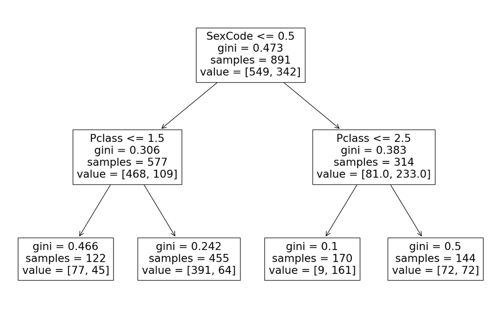

```python
from sklearn import tree
# Do a decision tree
clf = tree.DecisionTreeClassifier(max_depth=2, random_state = 0)
clf = clf.fit(X,Y)
plt.figure(figsize=(16,10))
tree.plot_tree(clf,feature_names=['SexCode','Pclass'])
```

c. Interpet the decision tree in the following cell.

**Parent Node:** Write your interpretation for the parent node. ***This parent node splits the dataset based on SexCode, which likely encodes gender (e.g., 0 for male, 1 for female). The left path (where SexCode <= 0.5) would include samples with a SexCode value of 0 (possibly males), while the right path (where SexCode > 0.5) includes those with a SexCode of 1 (possibly females).**

- **Left Path: Depth 1, Left Child:** Write your interpretation here.

***This node further splits the samples with SexCode <= 0.5 (possibly males) based on Pclass. The lower Gini impurity suggests that this split provides a somewhat clearer separation of classes.** * **Depth 2, Left Child:** Write your interpretation here. * **These are samples where SexCode <= 0.5 and Pclass <= 1.5, possibly indicating males in the first class. The Gini impurity is relatively high, indicating that the node still contains a mix of both classes, but with a slight majority in the first class.** * **Depth 2, Right Child:** Write your interpretation here. * **These are samples where SexCode <= 0.5 and Pclass > 1.5, possibly indicating males in second or third class. The low Gini impurity suggests a high concentration of one class (e.g., majority of non-survivors, if that’s what class 0 represents).**

- **Right Path: Depth 1, Right Child:** Write your interpretation here.
- **This node handles samples with SexCode > 0.5 (possibly females) and further splits them based on Pclass. The moderate Gini impurity suggests a fairly balanced distribution but with a stronger presence of one class.**
  - **Depth 2, Left Child:** Write your interpretation here.
  - **These are samples where SexCode > 0.5 and Pclass <= 2.5, possibly indicating females in first or second class. The very low Gini impurity indicates that this group is highly concentrated in one class (majority survivors).**
  - **Depth 2, Right Child:** Write your interpretation here.
  - **These are samples where SexCode > 0.5 and Pclass > 2.5, possibly indicating females in the third class. The Gini impurity of 0.5 suggests a balanced split between the two classes, indicating an equal likelihood of being in either class.**

d. Based on Gini score which node has the best classification (has lower impurity)? which node had the worst classification (has higher impurity)?

**Best Classification (Lowest Gini Impurity):** The node with the lowest Gini impurity is the Depth 2, Left Child on the right path with a Gini score of 0.1. This node has 170 samples with a value of [9, 161], indicating a highly pure classification where the majority of samples fall into one class.

**Worst Classification (Highest Gini Impurity):** The node with the highest Gini impurity is the Depth 2, Right Child on the right path with a Gini score of 0.5. This node has 144 samples with a value of [72, 72], indicating an equal split between the two classes, resulting in the highest impurity.

**Question 5:**

a. In the following, type a code to show the importance of each feature.

```python
X = df[['SexCode','Pclass']]
Y = df['Survived']
clf.feature_importances_
```

```
array([0.75132769, 0.24867231])
```

b. In the following, Interpret the feature importance output. **the feature importance shows that SexCode is 75.13% important in predicting who survived. Also, it shows that Pclass is 24.87% important in predicting who survived.**

**Question6:**

a. In the following, type a code to create a confusion matrix.

```python
from sklearn.metrics import confusion_matrix
predictions= clf.predict(X)
cm = confusion_matrix(Y, predictions)
cm
```

```
array([[540,   9],
       [181, 161]], dtype=int64)
```

b. In the following, Interpret the confusion matrix.

- **Upper left number:**

***True Positives (TP) = 540: The model correctly predicted 540 instances of class 0 (actual class was 0, and it was predicted as 0).**

- **Upper right number:**

***False Negatives (FN) = 9: The model incorrectly predicted 9 instances of class 1 when the actual class was 0 (actual class was 0, but it was predicted as 1).**

- **Bottom left number:**

***False Positives (FP) = 181:The model incorrectly predicted 181 instances of class 0 when the actual class was 1 (actual class was 1, but it was predicted as 0).**

- **Bottom right number:**

***True Negatives (TN) = 161: The model correctly predicted 161 instances of class 1 (actual class was 1, and it was predicted as 1).**

**Question 7: In the following, type a code to show the accuracy of your model.**

```python
# And, how accurate is our model?
accuracy = clf.score(X,Y)
print("Your decision tree is {:.2f}% accurate.".format(accuracy*100))
```

```
Your decision tree is 78.68% accurate.
```